# PS 812

Section 3: Simulation and Monte Carlo

John Hicks

Dept. of Political Science, UW-Madison

2026-09-25

# Announcements

## Problem Set 2

1. **Problem Set 2 is due Oct 6 at 11:59pm.**

# Today

## Today

**1. Random numbers in R**

Pseudo-randomness, `set.seed()`, and `runif()`

**2. Simulating from distributions**

`rnorm()`, `rexp()`, `rbinom()`, and the d/p/q/r family

**3. Iteration**

A `for` loop first, then as a function with `map()`

**4. Monte Carlo, LLN, and CLT**

Expectations and probabilities by simulation

**5. Application: the 2026 Senate**

# Random Numbers in R

## Computers can’t flip coins

- R generates **pseudo-random** numbers
- A deterministic algorithm yields a sequence of seemingly random numbers
- The algorithm uses an internal state, which each draw uses then updates
- R’s default algorithm is Mersenne-Twister:

```r
RNGkind()
```

```
[1] "Mersenne-Twister" "Inversion"        "Rejection"
```

## runif()

`runif()` draws from a Uniform(0, 1) distribution.

```r
runif(5)
```

```
[1] 0.5037611 0.6069089 0.8120073 0.8544792 0.4667540
```

```r
runif(5)
```

```
[1] 0.72735429 0.95132628 0.06079925 0.83190840 0.39553669
```

By default, it’s always different because the state changes.

## set.seed()

`set.seed()` fixes this by setting the starting state.

```r
set.seed(812)
runif(3)
```

```
[1] 0.03327772 0.70972903 0.80184214
```

```r
set.seed(812)
runif(3)
```

```
[1] 0.03327772 0.70972903 0.80184214
```

- Use it to make results reproducible across different code runs
- The number is arbitrary, as long as you don’t **seed-hack**

## Seeds

```r
set.seed(812)
a <- runif(3)
b <- runif(3)

set.seed(812)
c <- runif(6)

c(a, b)
```

```
[1] 0.03327772 0.70972903 0.80184214 0.72087339 0.28844627 0.64533598
```

```r
c
```

```
[1] 0.03327772 0.70972903 0.80184214 0.72087339 0.28844627 0.64533598
```

- Set the seed once at the start

## From uniform to anything

If $U \sim \text{Unif}(0,1)$ and $F$ is a CDF, then $F^{-1}(U)$ has CDF $F$.

In R, $F^{-1}$ is the `q` function:

```r
set.seed(812)
u <- runif(10000)
y <- qexp(u, rate = 0.25)

mean(y)
```

```
[1] 3.940406
```

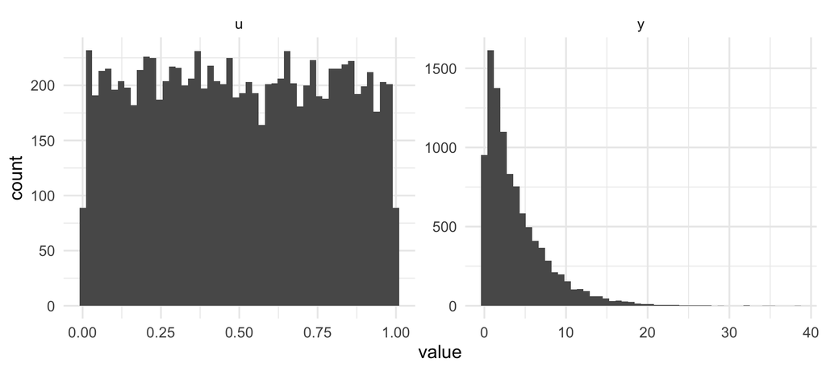

```r
tibble(u = u, y = y) |>
  pivot_longer(everything()) |>
  ggplot(aes(value)) +
  geom_histogram(bins = 50) +
  facet_wrap(~ name, scales = "free")
```

`rnorm()` does exactly this by default. That’s the `"Inversion"` in `RNGkind()`.

# Simulating from Distributions

## The d/p/q/r family

Every distribution in R comes with four functions:

| Prefix | Gives you | Normal example |
| --- | --- | --- |
| `d` | density (PDF) or mass (PMF) | `dnorm(0)` |
| `p` | CDF, $P(X \le x)$ | `pnorm(1.96)` |
| `q` | quantile, the inverse CDF | `qnorm(0.975)` |
| `r` | random draws | `rnorm(100)` |

Swap the suffix for other distributions: `unif`, `norm`, `exp`, `binom`, `pois`, `geom`, `t`, `chisq`, …

## Normal

```r
set.seed(812)
x <- rnorm(10000, mean = 0, sd = 1)

mean(x)
```

```
[1] -0.01659565
```

```r
sd(x)
```

```
[1] 0.9867823
```

```r
# share of draws above 1.96, vs. the exact answer
mean(x > 1.96)
```

```
[1] 0.0218
```

```r
1 - pnorm(1.96)
```

```
[1] 0.0249979
```

```r
ggplot(tibble(x = x), aes(x)) +
  geom_histogram(aes(y = after_stat(density)), bins = 60, fill = "grey70") +
  geom_function(fun = dnorm, colour = "#8B0000", linewidth = 1) +
  labs(title = "10,000 draws from N(0, 1) with the true density")
```

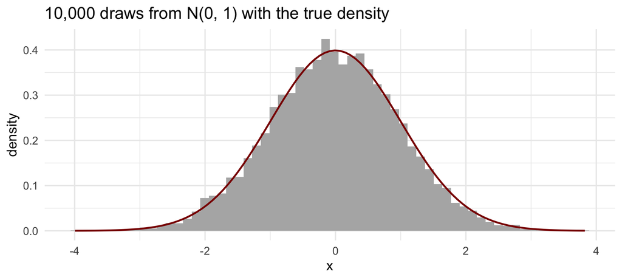

## Exponential

Waiting for the bus: $Y \sim \text{Exp}(\lambda = 0.25)$, so $E[Y] = 1/\lambda = 4$ minutes.

```r
set.seed(812)
y <- rexp(10000, rate = 0.25)

mean(y)
```

```
[1] 4.046211
```

```r
# P(2 <= Y <= 10): simulated vs. exact
mean(y >= 2 & y <= 10)
```

```
[1] 0.5351
```

```r
pexp(10, rate = 0.25) - pexp(2, rate = 0.25)
```

```
[1] 0.5244457
```

## Bernoulli and Binomial

```r
set.seed(812)

# Bernoulli(p=0.5) or 10 coin flips
rbinom(10, size = 1, prob = 0.5)
```

```
 [1] 0 1 1 1 0 1 0 1 0 1
```

```r
# Binom(n=20,p=0.3) or 10 sets of 20 30% chance coin flips
rbinom(10, size = 20, prob = 0.3)
```

```
 [1]  8  8 10  4  4  8  7  4  4  4
```

```r
# a Bernoulli by hand: TRUE with probability p
runif(10) < 0.3
```

```
 [1] FALSE FALSE  TRUE  TRUE FALSE  TRUE  TRUE FALSE  TRUE FALSE
```

The last one comes back on the Senate exercise.

## Check the parameterization

Pay attention to the parameters

- `rnorm()` takes the **SD**, not the variance
- `rexp()` takes the **rate**, not the mean
- `rgeom()` counts **failures before the first success**, so its mean is $(1-p)/p$, not $1/p$

```r
set.seed(812)
mean(rgeom(100000, prob = 0.2))       # about 4, not 5
```

```
[1] 4.02241
```

```r
mean(rgeom(100000, prob = 0.2) + 1)   # trials until first success: about 5
```

```
[1] 5.01878
```

# Iteration

## Why we need loops

A Monte Carlo simulation is:

1. Run one random experiment
2. Record the result
3. Repeat many times
4. Summarize the results

Step 3 is a loop.

## A for loop

```r
for (i in 1:5) {
  print(i^2)
}
```

```
[1] 1
[1] 4
[1] 9
[1] 16
[1] 25
```

- `i` takes each value in `1:5`, one at a time
- Everything inside `{ }` runs once per value

## Storing results

Example: roll two dice. What’s $P(\text{sum} = 7)$?

```r
set.seed(812)
n_sims <- 10000

results <- numeric(n_sims)   # empty vector to fill in

for (i in 1:n_sims) {
  dice <- sample(1:6, size = 2, replace = TRUE)
  results[i] <- sum(dice)
}

head(results)
```

```
[1]  6 10 10  7  8  7
```

```r
mean(results == 7)
```

```
[1] 0.1688
```

```r
6 / 36
```

```
[1] 0.1666667
```

## Don’t grow vectors inside a loop

Make the empty vector first (`numeric(n_sims)`) and fill it in. Don’t append with `c()`:

```r
n <- 30000

system.time({
  grown <- c()
  for (i in 1:n) grown <- c(grown, runif(1))   # copies the whole vector every time
})
```

```
   user  system elapsed
  0.738   0.176   0.917
```

```r
system.time({
  filled <- numeric(n)
  for (i in 1:n) filled[i] <- runif(1)
})
```

```
   user  system elapsed
  0.012   0.000   0.013
```

## Don’t set seed inside a loop

```r
results <- numeric(5)

for (i in 1:5) {
  set.seed(812)            # resets the stream every iteration
  results[i] <- runif(1)
}

results
```

```
[1] 0.03327772 0.03327772 0.03327772 0.03327772 0.03327772
```

## Functionalized version

```r
roll_two <- function() {
  dice <- sample(1:6, size = 2, replace = TRUE)
  sum(dice)
}

roll_two()
```

```
[1] 7
```

```r
roll_two()
```

```
[1] 9
```

The loop gets shorter:

```r
set.seed(812)
results <- numeric(n_sims)
for (i in 1:n_sims) {
  results[i] <- roll_two()
}
mean(results == 7)
```

```
[1] 0.1688
```

## Instead of for-looping: map() and replicate()

```r
set.seed(812)

# purrr: call the function once for each element of 1:n_sims
results <- map_int(1:n_sims, \(i) roll_two())
mean(results == 7)
```

```
[1] 0.1688
```

```r
# base R equivalent
results <- replicate(n_sims, roll_two())
mean(results == 7)
```

```
[1] 0.1688
```

- `\(i)` means `function(i)`. We ignore `i` because every experiment is the same
- `map_int()` returns integers, `map_dbl()` numbers, `map_lgl()` TRUE/FALSE, `map()` a list
- A preallocated `for` loop is not slow. The payoff is readable, reusable code

## Functions with arguments

We can modify a functionalized input through its arguments

```r
roll_n <- function(n_dice) {
  sum(sample(1:6, size = n_dice, replace = TRUE))
}

set.seed(812)
avg_sum <- map_dbl(1:6, \(k) mean(replicate(5000, roll_n(k))))

tibble(n_dice = 1:6, simulated = avg_sum, exact = 3.5 * (1:6))
```

```
# A tibble: 6 x 3
  n_dice simulated exact
   <int>     <dbl> <dbl>
1      1      3.47   3.5
2      2      7.01   7
3      3     10.6   10.5
4      4     13.9   14
5      5     17.5   17.5
6      6     21.0   21
```

# Monte Carlo

## The idea

Approximate a tough calculation with the average of many simulated draws.

$$E[g(X)] = \int g(x) f(x)\, dx \;\approx\; \frac{1}{M}\sum_{i=1}^{M} g\big(x^{(i)}\big), \qquad x^{(i)} \sim f$$

A probability is an expectation of an indicator: $P(A) = E[\mathbf{1}\{A\}]$.

So `mean(results == 7)` **is** a Monte Carlo estimate.

## An expectation

$Y \sim \text{Exp}(0.25)$. What is $E\big[\sqrt{1 + Y}\big]$?

```r
set.seed(812)
y <- rexp(100000, rate = 0.25)
mean(sqrt(1 + y))
```

```
[1] 2.092164
```

```r
# numerical integration, for comparison
integrate(\(y) sqrt(1 + y) * dexp(y, rate = 0.25), lower = 0, upper = Inf)
```

```
2.091283 with absolute error < 1.2e-06
```

## A probability: the urn

An urn has 5 red and 5 green balls. Draw 4 without replacement. What’s the probability they’re all the same color?

```r
urn <- c(rep(1, 5), rep(0, 5))   # 1 = red, 0 = green

same_color <- function() {
  draw <- sample(urn, size = 4, replace = FALSE)
  sum(draw) %in% c(0, 4)
}

set.seed(812)
p_hat <- mean(replicate(100000, same_color()))
p_hat
```

```
[1] 0.04834
```

```r
2 * choose(5, 4) / choose(10, 4)   # exact
```

```
[1] 0.04761905
```

## How close is close enough?

A simulated proportion $\hat p$ from $M$ independent sims has **Monte Carlo standard error**

$$\text{SE}(\hat p) = \sqrt{\frac{\hat p (1 - \hat p)}{M}}$$

```r
sqrt(p_hat * (1 - p_hat) / 100000)
```

```
[1] 0.0006782569
```

- The error shrinks like $1/\sqrt{M}$
- 10x more precision costs 100x more simulations

# LLN and CLT

## Law of Large Numbers

As $n \to \infty$, the sample mean $\bar{X}_n$ converges to $E[X]$.

```r
set.seed(812)
paths <- map(1:5, \(p) {
  y <- rexp(5000, rate = 0.25)
  tibble(path = p, n = 1:5000, running_mean = cumsum(y) / (1:5000))
}) |> list_rbind()

ggplot(paths, aes(n, running_mean, group = path)) +
  geom_line(alpha = 0.7) +
  geom_hline(yintercept = 4, colour = "#8B0000", linetype = "dashed") +
  scale_x_log10() +
  labs(x = "Number of draws (log scale)", y = "Running mean",
       title = "Five running means of Exp(0.25) draws, true mean = 4")
```

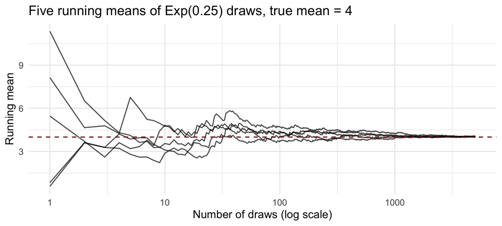

## Why Monte Carlo works

- Every Monte Carlo estimate is a sample mean of simulated draws
- The LLN says that sample mean converges to the thing we want
- More sims, closer answer. The SE tells you how close

## Central Limit Theorem

For iid draws with mean $\mu$ and variance $\sigma^2$, the sample mean is approximately normal for large $n$:

$$\bar{X}_n \;\approx\; N\!\left(\mu,\; \frac{\sigma^2}{n}\right)$$

This holds **even when $X$ itself is not normal**. The exponential is skewed. Take the mean of $n$ draws, 5,000 times:

```r
sample_mean <- function(n) mean(rexp(n, rate = 0.25))

set.seed(812)
clt <- map(c(1, 5, 30, 200), \(n) {
  tibble(n = n, xbar = replicate(5000, sample_mean(n)))
}) |> list_rbind()
```

```r
# the normal density the CLT predicts, for each n: N(4, 16/n)
curves <- expand_grid(n = c(1, 5, 30, 200), x = seq(0, 20, length.out = 400)) |>
  mutate(density = dnorm(x, mean = 4, sd = 4 / sqrt(n)))

ggplot(clt, aes(xbar)) +
  geom_histogram(aes(y = after_stat(density)), bins = 50, fill = "grey70") +
  geom_line(data = curves, aes(x, density), colour = "#8B0000", linewidth = 1) +
  facet_wrap(~ n, scales = "free", labeller = label_both, nrow = 1) +
  labs(x = "Sample mean", y = "Density")
```

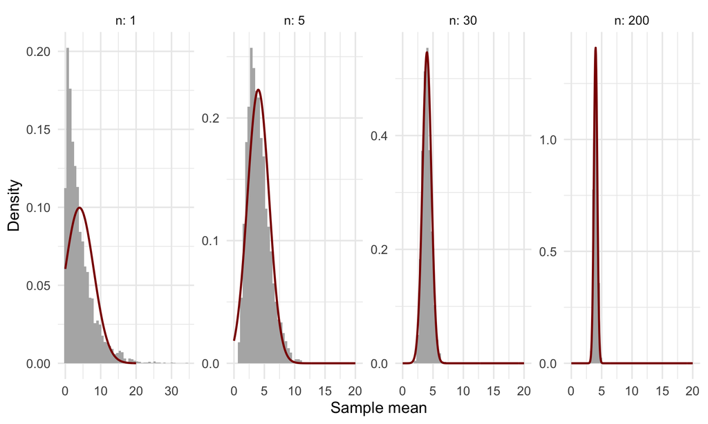

## Even a coin flip

$X \sim \text{Bernoulli}(0.1)$ only takes the values 0 and 1. The mean of $n$ flips:

```r
set.seed(812)
flips <- map(c(1, 10, 50, 500), \(n) {
  tibble(n = n, xbar = replicate(5000, mean(rbinom(n, size = 1, prob = 0.1))))
}) |> list_rbind()

ggplot(flips, aes(xbar)) +
  geom_histogram(bins = 30, fill = "grey70") +
  facet_wrap(~ n, scales = "free", labeller = label_both, nrow = 1) +
  labs(x = "Share of heads", y = "Simulations")
```

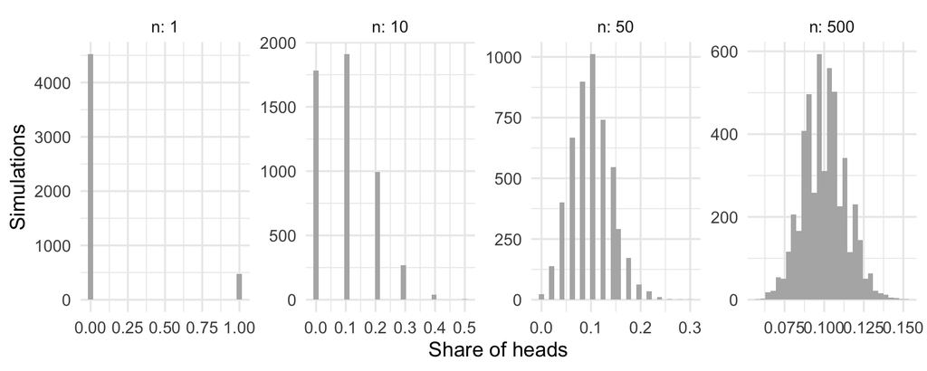

## LLN vs. CLT

- **LLN:** *where* the sample mean ends up ($\mu$)
- **CLT:** the *shape* of its error around $\mu$ (normal, with SD $\sigma/\sqrt{n}$)

# Application: the 2026 Senate

## What’s the probability Democrats win the Senate?

Split Ticket’s 2026 Senate model (published by *The Argument*, retrieved 9/23/2026). One row per race:

```r
senate <- read_csv("data/splitticket_senate_races_2026-09-23.csv")

senate |>
  select(state, dem_name, rep_name, margin, dem_prob, rating) |>
  arrange(abs(margin)) |>
  head(10)
```

```
# A tibble: 10 x 6
   state dem_name       rep_name        margin dem_prob rating
   <chr> <chr>          <chr>            <dbl>    <dbl> <chr>
 1 AK    Mary Peltola   Dan Sullivan       1         56 Tossup
 2 TX    James Talarico Ken Paxton         1.8       60 Lean D
 3 IA    Josh Turek     Ashley Hinson     -2.7       34 Lean R
 4 ME    Troy Jackson   Susan Collins      3.1       68 Lean D
 5 OH    Sherrod Brown  Jon Husted         3.5       70 Lean D
 6 MI    Abdul El-Sayed Mike Rogers        4.7       75 Lean D
 7 KS    Adam Hamilton  Roger Marshall    -6.1       16 Likely R
 8 NE    Dan Osborn     Pete Ricketts     -6.6       13 Likely R
 9 NC    Roy Cooper     Michael Whatley    6.8       84 Likely D
10 SC    Annie Andrews  Darline Graham    -6.9       13 Likely R
```

## Setup

- The Democratic caucus has 47 seats. 13 are up this year, so **34** are not on the ballot
- 35 races this year
- With a Republican VP breaking ties, Democrats need **51** seats
- Following Split Ticket, a win by one of the four independents (ID, MT, NE, SD) counts as a Democratic seat

Each race is a Bernoulli random variable, $X_s \sim \text{Bern}(p_s)$:

$$\text{Dem seats} = 34 + \sum_{s=1}^{35} X_s$$

## Why simulate?

- $E[\text{Dem seats}]$ is easy (linearity of expectation)
- But control depends on $P(\text{Dem seats} \ge 51)$, which needs the **whole distribution** of the sum
- A sum of 35 Bernoullis with 35 different $p$’s isn’t something you want to work out by hand
- So we simulate it

## Model 1: independent coin flips

- Flip 35 coins, each with its own probability of heads: `runif(35) < p`
- Count the heads, add 34
- Repeat many times
- Takes the published probabilities at face value

## Model 2: simulate the margins

Suppose the real margin is the forecast margin plus a normal error:

$$\text{margin}_s + \varepsilon_s, \qquad \varepsilon_s \sim N(0, s^2)
\quad\Rightarrow\quad
P(\text{D wins}) = P(\varepsilon_s > -\text{margin}_s) = \Phi\!\left(\frac{\text{margin}_s}{s}\right)$$

- Draw 35 errors, add them to the forecast margins, count the races above 0
- We need a value for $s$: how uncertain are the margins?

## Margins and probabilities

```r
ggplot(senate, aes(margin, dem_prob / 100)) +
  geom_point(size = 3) +
  labs(x = "Forecast margin (D - R)", y = "P(D wins)")
```

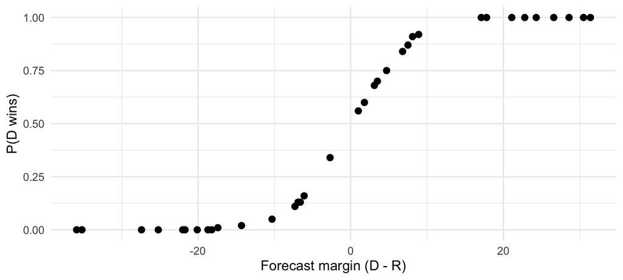

Which curve fits these points, and what $s$ does it imply?

# Exercise

## Exercise

Open `ps812_section3_exercise.qmd`.

- Part 1: seeds, distributions, loops, LLN, CLT
- Part 2: the Senate forecast